# Modèles de survie en R

Durée de grèves et cycle économique

Pierre Beaucoral

2026-10-16

```r
knitr::opts_chunk$set(fig.width = 7, fig.height = 4, fig.align = "center")

library(survival)
library(AER)      # StrikeDuration
library(dplyr)
library(ggplot2)

if (requireNamespace("survminer", quietly = TRUE)) {
  library(survminer)
}

# -------------------------
# Données brutes de grève
# -------------------------
data("StrikeDuration")
strikes_raw <- StrikeDuration

# Construction d'un jeu de données pour le TD
# - on crée une censure artificielle à 200 jours
# - on construit 2 versions catégorielles du choc d'activité
strikes <- strikes_raw |>
  mutate(
    # variable de durée
    time   = pmin(duration, 200),
    status = ifelse(duration > 200, 0, 1),  # 1 = fin de grève observée avant 200, 0 = censuré à 200

    # choc d'activité non anticipé (déjà continu) :
    #   uoutput > 0 -> cycle favorable ; < 0 -> cycle défavorable
    uoutput_sign = case_when(
      uoutput < 0  ~ "Cycle défavorable",
      uoutput == 0 ~ "Cycle neutre",
      uoutput > 0  ~ "Cycle favorable"
    ),

    # version en 3 classes par terciles (plutôt pour les KM)
    uoutput_q = cut(
      uoutput,
      breaks = quantile(uoutput, probs = c(0, .33, .66, 1), na.rm = TRUE),
      labels = c("Choc faible", "Choc moyen", "Choc fort"),
      include.lowest = TRUE
    )
  )

# Objet de survie pour les grèves (avec censure artificielle à 200 jours)
S_strikes <- Surv(time = strikes$time, event = strikes$status)
```

# 1 1. Notions de base & censure

## 1.1 Données de durée de vie

- On s’intéresse à une **durée** $T$ (positive) :
  - durée d’une grève
  - durée de chômage
  - durée de séjour à l’hôpital, etc.
- Pour chaque unité (grève) $i = 1,\dots,n$ :
  - $t_i$ : durée observée
  - $\delta_i$ : indicatrice d’événement
    - $\delta_i = 1$ si l’événement est observé (fin de grève avant la date limite)
    - $\delta_i = 0$ si la durée est **censurée** (on sait juste que la grève dure au moins jusqu’à $t_i$)

En R, on encode $(t_i, \delta_i)$ avec `Surv()`.

## 1.2 Fonctions de survie & de risque

- **Fonction de survie** :
  $$S(t) = \Pr(T > t)$$
  Probabilité que la grève soit encore en cours à la date $t$.
- **Fonction de répartition** :
  $$F(t) = \Pr(T \le t) = 1 - S(t)$$
- **Fonction de risque (hazard)** :
  $$h(t) = \lim_{\Delta t \to 0}
  \frac{\Pr(t \le T < t + \Delta t \mid T \ge t)}{\Delta t}$$

  → “probabilité instantanée” que la grève se termine juste après $t$, sachant qu’elle durait encore à $t$.

## 1.3 Lien $S(t)$ – $h(t)$

- En continu, on a :
  $$S(t) = \exp\left(-\int_0^t h(u)\,du\right)$$
- Cas simple : **risque constant** $h(t) = \lambda$  
  → $S(t) = \exp(-\lambda t)$ (modèle exponentiel)

## 1.4 Censure à droite

- On ne connaît pas toujours la date exacte de fin :
  - fin de la période d’observation alors que la grève continue
  - données administratives tronquées
- On observe alors :
  - $t_i = \min(T_i, C_i)$
  - $\delta_i = \mathbb{1}(T_i \le C_i)$
- Hypothèse clé : **censure non informative**  
  → le mécanisme de censure est indépendant de la durée sous-jacente, conditionnellement aux covariables.

## 1.5 Censure à droite – Rappel R

```r
# Objet de survie pour les grèves (avec censure artificielle à 200 jours)
S_strikes <- Surv(time = strikes$time, event = strikes$status)
head(S_strikes)
```

```
[1]  7  9 13 14 26 29
```

# 2 2. Kaplan–Meier & log-rank dans R

## 2.1 Estimateur Kaplan–Meier

- But : estimer $S(t)$ **sans paramètre** (non paramétrique)
- On empile les durées ordonnées où surviennent des événements :
  - à chaque temps $t_j$, on observe $d_j$ événements parmi $n_j$ grèves encore en cours.
- Estimateur :
  $$\hat S(t) = \prod_{t_j \le t} \left(1 - \frac{d_j}{n_j}\right)$$

## 2.2 Kaplan–Meier en R

```r
km_all <- survfit(S_strikes ~ 1, data = strikes)
km_all
```

```
Call: survfit(formula = S_strikes ~ 1, data = strikes)

      n events median 0.95LCL 0.95UCL
[1,] 62     61     27      21      41
```

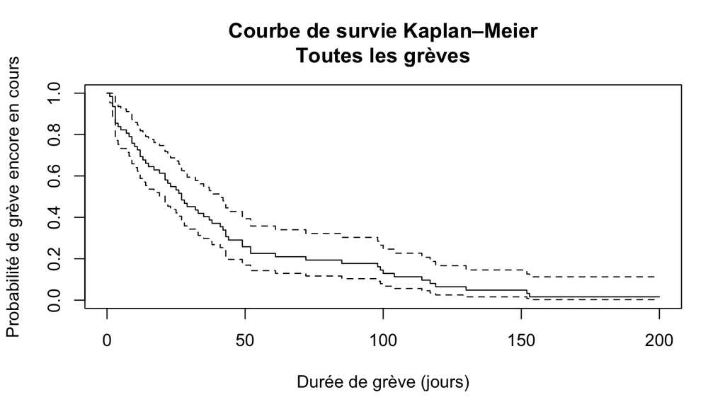

```r
plot(km_all, xlab = "Durée de grève (jours)", ylab = "Probabilité de grève encore en cours",
     main = "Courbe de survie Kaplan–Meier\nToutes les grèves")
```

Ou avec `{survminer}` :

```r
if (requireNamespace("survminer", quietly = TRUE)) {
  ggsurvplot(km_all, conf.int = TRUE,
             xlab = "Durée de grève (jours)",
             ylab = "Probabilité de grève en cours")
}
```

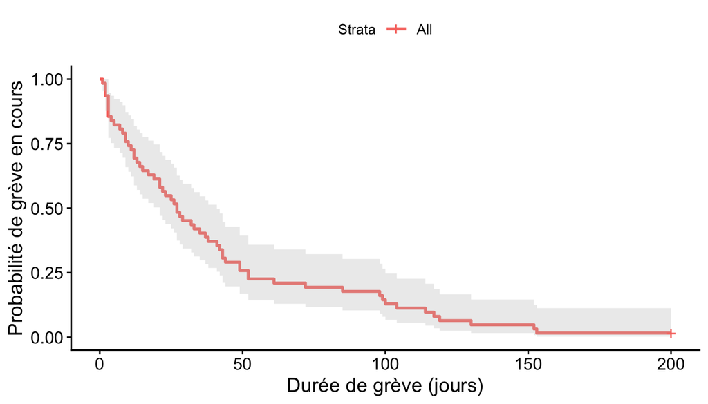

## 2.3 Kaplan–Meier par groupes

On veut comparer la durée des grèves selon le **choc d’activité** :

```r
km_cycle <- survfit(S_strikes ~ uoutput_q, data = strikes)
summary(km_cycle)
```

```
Call: survfit(formula = S_strikes ~ uoutput_q, data = strikes)

                uoutput_q=Choc faible
 time n.risk n.event survival std.err lower 95% CI upper 95% CI
    2     25       1     0.96  0.0392      0.88618        1.000
    3     24       1     0.92  0.0543      0.81957        1.000
    5     23       1     0.88  0.0650      0.76141        1.000
   12     22       2     0.80  0.0800      0.65761        0.973
   15     20       1     0.76  0.0854      0.60974        0.947
   17     19       1     0.72  0.0898      0.56386        0.919
   19     18       1     0.68  0.0933      0.51967        0.890
   21     17       2     0.60  0.0980      0.43566        0.826
   27     15       1     0.56  0.0993      0.39563        0.793
   28     14       1     0.52  0.0999      0.35681        0.758
   38     13       1     0.48  0.0999      0.31919        0.722
```

[output cut: 48 more lines]

```r
if (requireNamespace("survminer", quietly = TRUE)) {
  ggsurvplot(km_cycle, data = strikes,
             conf.int = FALSE, pval = TRUE,
             legend.title = "Choc d'activité",
             legend.labs  = levels(strikes$uoutput_q),
             xlab = "Durée de grève (jours)",
             ylab = "Probabilité de grève en cours")
}
```

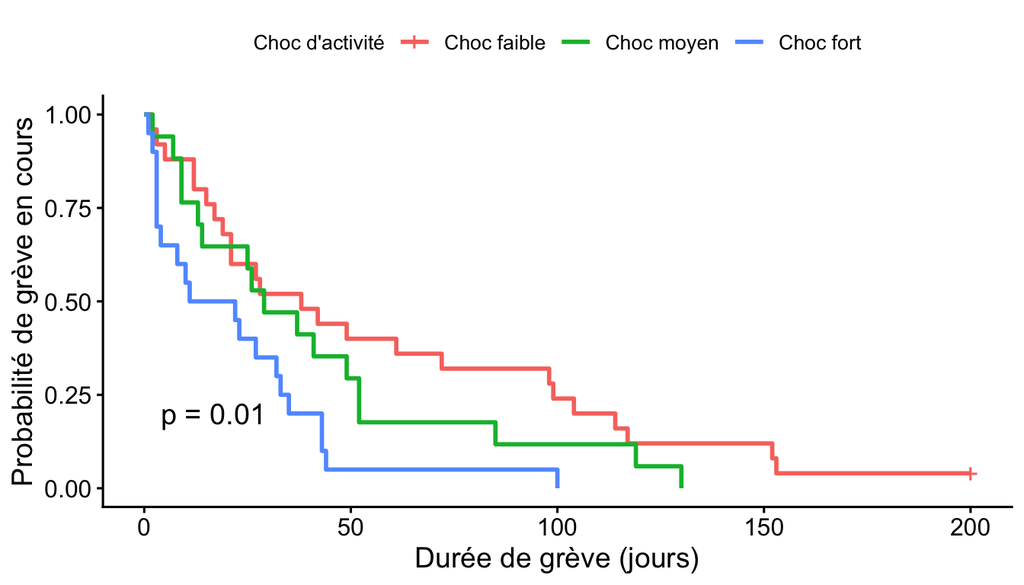

## 2.4 Test du log-rank

- Hypothèse nulle $H_0$ : **même fonction de survie** dans tous les groupes
- Statistique de test $\chi^2$ :
  - compare, à chaque temps $t_j$, les **événements observés vs attendus** dans chaque groupe.

En R :

```r
survdiff(S_strikes ~ uoutput_q, data = strikes)
```

```
Call:
survdiff(formula = S_strikes ~ uoutput_q, data = strikes)

                       N Observed Expected (O-E)^2/E (O-E)^2/V
uoutput_q=Choc faible 25       24     32.4  2.198928  5.143950
uoutput_q=Choc moyen  17       17     16.9  0.000153  0.000219
uoutput_q=Choc fort   20       20     11.6  6.074740  8.183882

 Chisq= 9.2  on 2 degrees of freedom, p= 0.01
```

- Le test du log-rank compare les courbes de survie des trois groupes de choc (`Choc faible`, `Choc moyen`, `Choc fort`) sous

  $H_0$ : même fonction de survie pour les trois groupes.
- La statistique de test $\chi^2 = 9{,}2$ avec 2 ddl donne une p-valeur de 0,01. → Au seuil de 5 %, on **rejette** $H_0$ : la durée des grèves dépend significativement du niveau de choc d’activité.

# 3 3. Modèle de Cox

## 3.1 Modèle de Cox – rappel

- Modèle des **risques proportionnels** :
  $$h_i(t) = h_0(t)\,\exp(\beta_1 x_{i1} + \dots + \beta_p x_{ip})$$
- $h_0(t)$ : **baseline hazard** (fonction de risque de référence, non paramétrique)
- Interprétation des coefficients :
  - $\exp(\beta_k)$ = **hazard ratio** pour un accroissement d’une unité de $x_k$
  - $> 1$ : grèves plus “rapides” à se terminer (durée plus courte)
  - $< 1$ : grèves plus longues

## 3.2 Cox en R – un seul prédicteur

```r
cox_uoutput <- coxph(S_strikes ~ uoutput, data = strikes)
summary(cox_uoutput)
```

```
Call:
coxph(formula = S_strikes ~ uoutput, data = strikes)

  n= 62, number of events= 61

             coef exp(coef)  se(coef)     z Pr(>|z|)
uoutput     9.216 10060.629     3.229 2.855  0.00431 **
---
Signif. codes:  0 '***' 0.001 '**' 0.01 '*' 0.05 '.' 0.1 ' ' 1

        exp(coef) exp(-coef) lower .95 upper .95
uoutput     10061   9.94e-05     17.96   5634413

Concordance= 0.608  (se = 0.041 )
Likelihood ratio test= 8.43  on 1 df,   p=0.004
Wald test            = 8.15  on 1 df,   p=0.004
Score (logrank) test = 8.31  on 1 df,   p=0.004
```

- `coef` : estimateur de $\beta$
- `exp(coef)` : hazard ratio
- `coxph` estime $\beta$ par **maximisation de la vraisemblance partielle**.

## 3.3 Cox en R – plusieurs prédicteurs

On peut enrichir avec une version catégorielle du choc :

```r
cox_multi <- coxph(S_strikes ~ uoutput + uoutput_q, data = strikes)
summary(cox_multi)
```

```
Call:
coxph(formula = S_strikes ~ uoutput + uoutput_q, data = strikes)

  n= 62, number of events= 61

                        coef exp(coef) se(coef)     z Pr(>|z|)
uoutput               5.7304  308.0941  10.2171 0.561    0.575
uoutput_qChoc moyen   0.0587    1.0604   0.6119 0.096    0.924
uoutput_qChoc fort    0.3886    1.4750   1.0638 0.365    0.715

                    exp(coef) exp(-coef) lower .95 upper .95
uoutput               308.094   0.003246 6.192e-07 1.533e+11
uoutput_qChoc moyen     1.060   0.942994 3.196e-01 3.518e+00
uoutput_qChoc fort      1.475   0.677978 1.833e-01 1.187e+01

Concordance= 0.608  (se = 0.041 )
Likelihood ratio test= 8.79  on 3 df,   p=0.03
Wald test            = 9.01  on 3 df,   p=0.03
Score (logrank) test = 9.52  on 3 df,   p=0.02
```

On comparera les modèles (quanti vs quali) plus tard, dans les exercices, via AIC et tests de rapport de vraisemblance.

## 3.4 Vérifier l’hypothèse de risques proportionnels

Test “graphique” : courbes de `log(-log(S(t)))` par groupe.  
Si les risques sont proportionnels, les courbes devraient être à peu près **parallèles**.

```r
if (requireNamespace("survminer", quietly = TRUE)) {
  ggsurvplot(
    survfit(S_strikes ~ uoutput_q, data = strikes),
    fun = "cloglog",    # log(-log(S))
    xlab = "log(temps)",
    ylab = "log(-log(Survie))",
    legend.title = "Choc d'activité"
  )
}
```

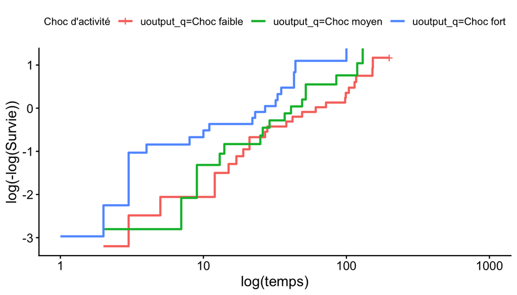

## 3.5 Test de Schoenfeld

En pratique, on utilise souvent les **résidus de Schoenfeld** :

```r
cox_zph <- cox.zph(cox_uoutput)
cox_zph
```

```
          chisq df    p
uoutput 0.00662  1 0.94
GLOBAL  0.00662  1 0.94
```

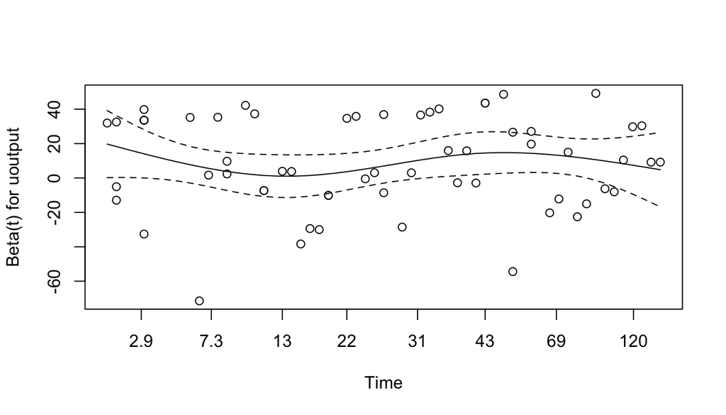

```r
plot(cox_zph)
```

- p-valeur petite → violation possible de l’hypothèse de PH pour le prédicteur concerné.

# 4 4. Modèles paramétriques

## 4.1 Weibull en risques proportionnels

- Cas où :
  $$h(t) = \lambda p t^{p-1}$$
- Si $p=1$ → modèle exponentiel
- Dans un cadre PH avec covariables :
  $$h_i(t) = \lambda p t^{p-1} \exp(\beta^\top x_i)$$

> **Intérêt? Plus d’efficacité si la forme est à peu près correcte:**
> - Si cette forme est *raisonnablement* proche de la réalité :
>   - estimation des $\beta$ plus **précise** (variance plus faible),
>   - meilleure performance en petits échantillons,
>   - courbes de survie plus lisses, moins “en escalier” que Kaplan–Meier.

En R :

```r
weib_ph <- survreg(S_strikes ~ uoutput, data = strikes, dist = "weibull")
summary(weib_ph)
```

```
Call:
survreg(formula = S_strikes ~ uoutput, data = strikes, dist = "weibull")
               Value Std. Error     z      p
(Intercept)  3.79012    0.13944 27.18 <2e-16
uoutput     -9.67700    3.00825 -3.22 0.0013
Log(scale)   0.00631    0.10180  0.06 0.9506

Scale= 1.01

Weibull distribution
Loglik(model)= -285.4   Loglik(intercept only)= -290.2
    Chisq= 9.6 on 1 degrees of freedom, p= 0.002
Number of Newton-Raphson Iterations: 6
n= 62
```

Attention : `survreg` utilise la paramétrisation **AFT**. On peut revenir à l’écriture PH via des transformations (cf. aide R).

## 4.2 Modèles AFT (Accelerated Failure Time)

- On suppose :
  $$\log T_i = \alpha + \beta^\top x_i + \varepsilon_i$$
- Selon la loi de $\varepsilon_i$, on obtient différents modèles :
  - normal → log-normal
  - logistique → log-logistique
  - Gumbel → Weibull (vu comme AFT)

En R, toujours via `survreg()` :

```r
aft_lognormal   <- survreg(S_strikes ~ uoutput, data = strikes, dist = "lognormal")
aft_loglogistic <- survreg(S_strikes ~ uoutput, data = strikes, dist = "loglogistic")
summary(aft_lognormal)
```

```
Call:
survreg(formula = S_strikes ~ uoutput, data = strikes, dist = "lognormal")
              Value Std. Error     z      p
(Intercept)  3.2155     0.1606 20.02 <2e-16
uoutput     -9.3664     3.3945 -2.76 0.0058
Log(scale)   0.2047     0.0909  2.25 0.0243

Scale= 1.23

Log Normal distribution
Loglik(model)= -287.4   Loglik(intercept only)= -291
    Chisq= 7.2 on 1 degrees of freedom, p= 0.0073
Number of Newton-Raphson Iterations: 3
n= 62
```

```r
summary(aft_loglogistic)
```

```
Call:
survreg(formula = S_strikes ~ uoutput, data = strikes, dist = "loglogistic")
             Value Std. Error     z      p
(Intercept)  3.295      0.165 19.99 <2e-16
uoutput     -9.615      3.625 -2.65 0.0080
Log(scale)  -0.333      0.105 -3.16 0.0016

Scale= 0.717

Log logistic distribution
Loglik(model)= -288.6   Loglik(intercept only)= -292
    Chisq= 6.85 on 1 degrees of freedom, p= 0.0088
Number of Newton-Raphson Iterations: 3
n= 62
```

# 5 5. Application : durée de grèves

## 5.1 Jeu de données StrikeDuration

- Données issues de Kennan (1985), *“The Duration of Contract Strikes in U.S. Manufacturing”*, Journal of Econometrics.
- 62 grèves dans l’industrie manufacturière US (1968–1976).
- Variables :
  - `duration` : durée de la grève (jours)
  - `uoutput` : choc d’activité non anticipé (mesure macro, liée à la conjoncture)

```r
summary(strikes_raw)
```

```
    duration         uoutput
 Min.   :  1.00   Min.   :-0.10443
 1st Qu.: 10.25   1st Qu.:-0.03143
 Median : 27.00   Median : 0.01138
 Mean   : 42.68   Mean   : 0.01102
 3rd Qu.: 51.25   3rd Qu.: 0.06450
 Max.   :216.00   Max.   : 0.07427
```

## 5.2 Construction des variables de TD

- On introduit :
  - une **censure artificielle** à 200 jours ;

  ```r
  summary(strikes)
  ```

  ```
      duration         uoutput              time            status
   Min.   :  1.00   Min.   :-0.10443   Min.   :  1.00   Min.   :0.0000
   1st Qu.: 10.25   1st Qu.:-0.03143   1st Qu.: 10.25   1st Qu.:1.0000
   Median : 27.00   Median : 0.01138   Median : 27.00   Median :1.0000
   Mean   : 42.68   Mean   : 0.01102   Mean   : 42.42   Mean   :0.9839
   3rd Qu.: 51.25   3rd Qu.: 0.06450   3rd Qu.: 51.25   3rd Qu.:1.0000
   Max.   :216.00   Max.   : 0.07427   Max.   :200.00   Max.   :1.0000
      uoutput_sign       uoutput_q
   Length   :62    Choc faible:25
   N.unique : 2    Choc moyen :17
   N.blank  : 0    Choc fort  :20
   Min.nchar:15
   Max.nchar:17
  ```

- deux codes pour le choc d’activité :
  - `uoutput_sign` : défavorable / favorable

  ```r
  table(strikes$uoutput_sign)
  ```

  ```
  Cycle défavorable   Cycle favorable
                 25                37
  ```

  - `uoutput_q` : choc faible / moyen / fort (terciles)

```r
table(strikes$uoutput_q)
```

```
Choc faible  Choc moyen   Choc fort
         25          17          20
```

# 6 6. Exercices – Énoncé (survie de grève)

## 6.1 1. Présentation des données et analyse descriptive

On considère les 62 grèves de la base `StrikeDuration`.

   ```r
   with(strikes, table(uoutput_sign, uoutput_q))
   ```

   ```
                      uoutput_q
   uoutput_sign        Choc faible Choc moyen Choc fort
     Cycle défavorable          25          0         0
     Cycle favorable             0         17        20
   ```

   ```r
   prop.table(with(strikes, table(uoutput_sign, uoutput_q)), 1)
   ```

   ```
                      uoutput_q
   uoutput_sign        Choc faible Choc moyen Choc fort
     Cycle défavorable   1.0000000  0.0000000 0.0000000
     Cycle favorable     0.0000000  0.4594595 0.5405405
   ```

## 6.2 1. Présentation des données et analyse descriptive (2)

2. **(Corrélations entre variables explicatives)**  
   On considère comme variables explicatives potentielles :
   - `uoutput` (continu)
   - une version numérique de `uoutput_q` (par ex. 1 = faible, 2 = moyen, 3 = fort)
   1. Construire une matrice de corrélations entre ces deux variables.
   2. Commenter : y a-t-il une information nouvelle dans la version catégorielle ?

   ```r
   strikes <- strikes |>
     mutate(uoutput_q_num = as.numeric(uoutput_q))

   cor(dplyr::select(strikes, uoutput, uoutput_q_num), use = "complete.obs")
   ```

   ```
                   uoutput uoutput_q_num
   uoutput       1.0000000     0.9245881
   uoutput_q_num 0.9245881     1.0000000
   ```

## 6.3 1. Présentation des données et analyse descriptive (3)

3. **(Courbes de survie brutes)**  
   On trace les courbes de survie Kaplan–Meier de la durée de grève selon `uoutput_q`.
   1. Que constate-t-on sur les différences de durée de grève selon le choc d’activité ?

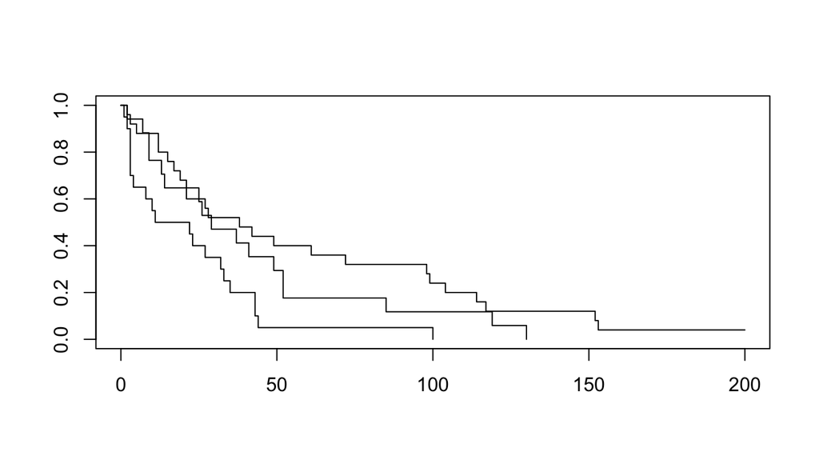

   ```r
   km_cycle <- survfit(S_strikes ~ uoutput_q, data = strikes)
   plot(km_cycle)
   ```

4. **(Test du log-rank)**  
   On utilise un test du log-rank pour tester l’effet global de `uoutput_q`.
   1. Écrire les hypothèses $H_0$ / $H_1$.
   2. Interpréter la statistique de test et la p-valeur.

   ```r
   survdiff(S_strikes ~ uoutput_q, data = strikes)
   ```

   ```
   Call:
   survdiff(formula = S_strikes ~ uoutput_q, data = strikes)

                          N Observed Expected (O-E)^2/E (O-E)^2/V
   uoutput_q=Choc faible 25       24     32.4  2.198928  5.143950
   uoutput_q=Choc moyen  17       17     16.9  0.000153  0.000219
   uoutput_q=Choc fort   20       20     11.6  6.074740  8.183882

    Chisq= 9.2  on 2 degrees of freedom, p= 0.01
   ```

## 6.4 1. Présentation des données et analyse descriptive (4)

5. **(Vérification graphique des risques proportionnels)**  
   On trace les courbes de `log(-log(S(t)))` par niveau de `uoutput_q`.
   1. Les courbes semblent-elles approximativement parallèles ?
   2. Conclure sur la plausibilité du modèle de Cox avec cette variable.

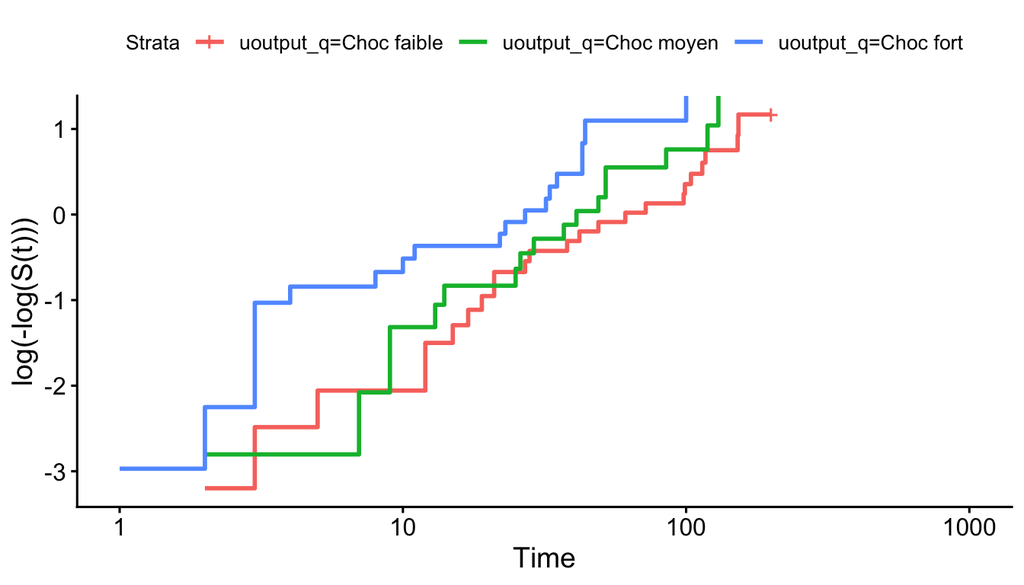

   ```r
   if (requireNamespace("survminer", quietly = TRUE)) {
     ggsurvplot(
       survfit(S_strikes ~ uoutput_q, data = strikes),
       fun = "cloglog"
     )
   }
   ```

# 7 Exercices – Correction (survie de grève)

## 7.1 Présentation des données et analyse descriptive

### 7.1.1 Q1 – Correspondance entre codages du cycle

On considère les 62 grèves de la base `StrikeDuration`.

On a construit :

- `uoutput_sign` : 2 modalités (cycle défavorable, favorable)
- `uoutput_q` : 3 modalités (choc faible, moyen, fort, par terciles)

```r
with(strikes, table(uoutput_sign, uoutput_q))
```

```
                   uoutput_q
uoutput_sign        Choc faible Choc moyen Choc fort
  Cycle défavorable          25          0         0
  Cycle favorable             0         17        20
```

```r
prop.table(with(strikes, table(uoutput_sign, uoutput_q)), 1)
```

```
                   uoutput_q
uoutput_sign        Choc faible Choc moyen Choc fort
  Cycle défavorable   1.0000000  0.0000000 0.0000000
  Cycle favorable     0.0000000  0.4594595 0.5405405
```

**Commentaires :**

- Tous les épisodes en **cycle défavorable** sont classés en `Choc faible`.
- Les épisodes en **cycle favorable** se répartissent entre `Choc moyen` et `Choc fort`.
- La matrice est quasi diagonale : les deux codages racontent la **même histoire** (choc défavorable vs favorable), l’un en version “signe”, l’autre en version “force du choc”.
- On peut donc considérer que les deux échelles sont **cohérentes**.

### 7.1.2 Q2 – Corrélations entre variables explicatives

Variables explicatives potentielles :

- `uoutput` (continu)
- `uoutput_q_num` : version numérique de `uoutput_q` (1 = faible, 2 = moyen, 3 = fort)

```r
strikes <- strikes |>
  mutate(uoutput_q_num = as.numeric(uoutput_q))

cor(dplyr::select(strikes, uoutput, uoutput_q_num), use = "complete.obs")
```

```
                uoutput uoutput_q_num
uoutput       1.0000000     0.9245881
uoutput_q_num 0.9245881     1.0000000
```

**Commentaires :**

- On obtient une **corrélation positive forte** entre `uoutput` et `uoutput_q_num` (la variable en terciles est une discrétisation monotone de `uoutput`).
- La version catégorielle n’apporte donc pas d’information entièrement nouvelle, mais elle permet :
  - de capturer plus facilement des **effets non linéaires** du choc,
  - de produire des comparaisons simples (`Choc faible` vs `Choc fort`) en termes de **hazard ratios**.

### 7.1.3 Q3 – Courbes de survie brutes (Kaplan–Meier)

```r
km_cycle <- survfit(S_strikes ~ uoutput_q, data = strikes)

plot(
  km_cycle,
  xlab = "Durée de grève (jours)",
  ylab = "Probabilité de grève en cours",
  col = c("black", "darkgray", "gray70"),   # 3 couleurs
  lty = c(1, 2, 3),                          # 3 types de ligne
  lwd = 2                                    # lignes plus épaisses
)

legend(
  "topright",
  legend = levels(strikes$uoutput_q),
  col    = c("black", "darkgray", "gray70"),
  lty    = c(1, 2, 3),
  lwd    = 2,
  bty    = "n"
)
```

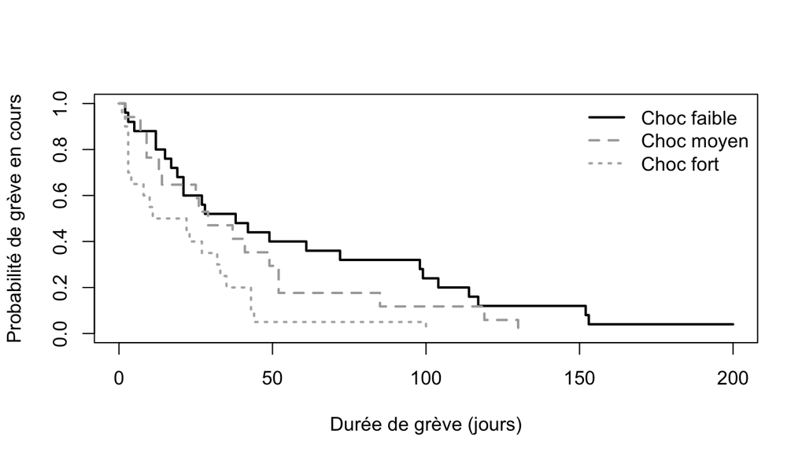

**Commentaires :**

- Pour les **chocs forts** (conjoncture très favorable), la courbe de survie décroît plus vite : les grèves ont tendance à être **plus courtes**.
- Pour les **chocs faibles** (conjoncture défavorable), la courbe décroît plus lentement : les grèves restent **plus longtemps en cours**.
- Les courbes sont bien séparées, ce qui suggère un **effet du contexte macroéconomique** sur la durée des grèves.

### 7.1.4 Q4 – Test du log-rank

```r
survdiff(S_strikes ~ uoutput_q, data = strikes)
```

```
Call:
survdiff(formula = S_strikes ~ uoutput_q, data = strikes)

                       N Observed Expected (O-E)^2/E (O-E)^2/V
uoutput_q=Choc faible 25       24     32.4  2.198928  5.143950
uoutput_q=Choc moyen  17       17     16.9  0.000153  0.000219
uoutput_q=Choc fort   20       20     11.6  6.074740  8.183882

 Chisq= 9.2  on 2 degrees of freedom, p= 0.01
```

**Commentaires :**

- Hypothèses du test du log-rank :
  - $H_0$ : les fonctions de survie sont **identiques** dans les 3 groupes de choc (`Choc faible`, `Choc moyen`, `Choc fort`).
  - $H_1$ : au moins une fonction de survie **diffère**.
- On obtient une statistique $\chi^2$ d’environ 9,2 avec 2 ddl et une p-valeur ≈ 0,01.
- Au seuil de 5 %, on **rejette** $H_0$ : la durée des grèves dépend significativement du niveau de choc d’activité.

### 7.1.5 Q5 – Vérification graphique des risques proportionnels

```r
if (requireNamespace("survminer", quietly = TRUE)) {
  ggsurvplot(
    survfit(S_strikes ~ uoutput_q, data = strikes),
    fun = "cloglog",
    xlab = "log(temps)",
    ylab = "log(-log(Survie))"
  )
}
```

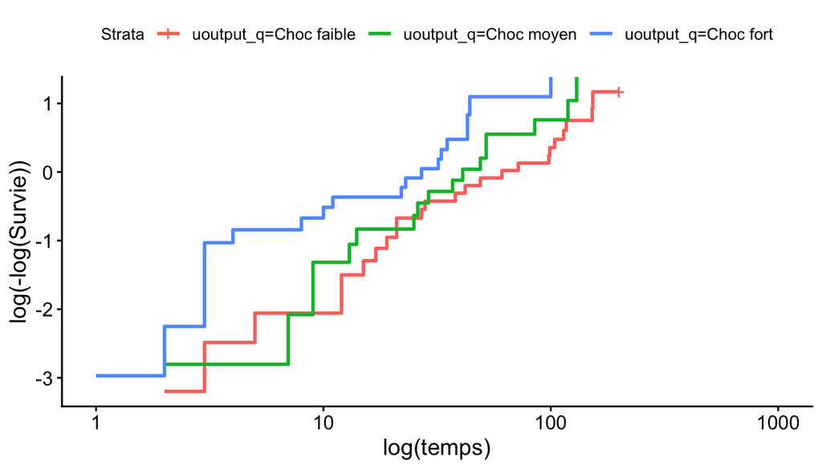

**Commentaires :**

## 7.2 2. Modèle de Cox – Correction

### 7.2.1 Q6 – Modèle de Cox continu

Modèle ajusté :

```r
cox_full <- coxph(S_strikes ~ uoutput + uoutput_q_num, data = strikes)
summary(cox_full)
```

```
Call:
coxph(formula = S_strikes ~ uoutput + uoutput_q_num, data = strikes)

  n= 62, number of events= 61

                  coef exp(coef) se(coef)     z Pr(>|z|)
uoutput         5.5249  250.8571  10.3206 0.535    0.592
uoutput_q_num   0.2007    1.2223   0.5385 0.373    0.709

              exp(coef) exp(-coef) lower .95 upper .95
uoutput         250.857   0.003986 4.117e-07 1.529e+11
uoutput_q_num     1.222   0.818155 4.254e-01 3.512e+00

Concordance= 0.608  (se = 0.041 )
Likelihood ratio test= 8.57  on 2 df,   p=0.01
Wald test            = 8.5  on 2 df,   p=0.01
Score (logrank) test = 8.83  on 2 df,   p=0.01
```

```r
AIC(cox_full)
```

```
[1] 389.1666
```

**Équation du modèle :**

$h_i(t) = h_0(t)\,\exp\big( \eta_1\,uoutput_i + \eta_2\,uoutput_{q,i} \big)$

**Interprétation du coefficient de `uoutput` :**

- Le terme $\exp(\eta_1)$ est le **hazard ratio** associé à une augmentation d’une unité de `uoutput`.
- Comme `uoutput` est un choc macro **petit en amplitude**, on interprète plutôt de petites variations (par ex. aller d’un quantile faible à un quantile élevé).
- Si $\exp(\eta_1) > 1$, un choc plus favorable est associé à une **fin plus rapide** de la grève (durées plus courtes).

### 7.2.2 Q7 – Version purement catégorielle du cycle

```r
cox_cat <- coxph(S_strikes ~ uoutput_q, data = strikes)
summary(cox_cat)
```

```
Call:
coxph(formula = S_strikes ~ uoutput_q, data = strikes)

  n= 62, number of events= 61

                      coef exp(coef) se(coef)     z Pr(>|z|)
uoutput_qChoc moyen 0.3556    1.4271   0.3253 1.093  0.27435
uoutput_qChoc fort  0.9643    2.6229   0.3265 2.954  0.00314 **
---
Signif. codes:  0 '***' 0.001 '**' 0.01 '*' 0.05 '.' 0.1 ' ' 1

                    exp(coef) exp(-coef) lower .95 upper .95
uoutput_qChoc moyen     1.427     0.7007    0.7543     2.700
uoutput_qChoc fort      2.623     0.3813    1.3832     4.974

Concordance= 0.604  (se = 0.039 )
Likelihood ratio test= 8.47  on 2 df,   p=0.01
Wald test            = 8.81  on 2 df,   p=0.01
Score (logrank) test = 9.3  on 2 df,   p=0.01
```

**Équation du modèle :**

$h_i(t) = h_0(t)\,\exp\big( \eta_2\,\mathbb{1}\{\,uoutput_{q,i} = \text{Choc moyen}\} + \eta_3\,\mathbb{1}\{\,uoutput_{q,i} = \text{Choc fort}\} \big).$

avec `Choc faible` comme catégorie de référence.

**Interprétation :**

- $\exp(\eta_2)$ : hazard ratio “Choc moyen” vs “Choc faible”.
- $\exp(\eta_3)$ : hazard ratio “Choc fort” vs “Choc faible”.
- Si au moins un coefficient est significatif, on conclut à une **différence de durée** entre au moins deux niveaux de choc.
- En pratique, avec ce petit échantillon, les intervalles de confiance sont larges → significativité parfois fragile, mais la direction va vers des **grèves plus rapides** en cas de choc plus fort.

**Comparaison des déviances :**

- On lit les log-vraisemblances de `cox_full` et `cox_cat` dans les sorties et l’on compare :
  - une **déviance plus faible** $(-2\log L)$ indique un meilleur ajustement (à nombre de paramètres donné).

### 7.2.3 Q8 – Nombre de paramètres

**Emboîtement :**

### 7.2.4 Q9 – Choix de la meilleure mesure du cycle

```r
cox_M1 <- coxph(S_strikes ~ uoutput, data = strikes)
cox_M2 <- coxph(S_strikes ~ uoutput + uoutput_q, data = strikes)
cox_M3 <- coxph(S_strikes ~ uoutput_q, data = strikes)

anova(cox_M1, cox_M2, test = "LRT")
```

```
Analysis of Deviance Table
 Cox model: response is  S_strikes
 Model 1: ~ uoutput
 Model 2: ~ uoutput + uoutput_q
   loglik  Chisq Df Pr(>|Chi|)
1 -192.65
2 -192.47 0.3621  2     0.8344
```

```r
anova(cox_M1, cox_M3, test = "LRT")
```

```
Analysis of Deviance Table
 Cox model: response is  S_strikes
 Model 1: ~ uoutput
 Model 2: ~ uoutput_q
   loglik  Chisq Df Pr(>|Chi|)
1 -192.65
2 -192.63 0.0382  1      0.845
```

## 7.3 3. Modèles paramétriques – Correction

### 7.3.1 Q10 – Modèle de Weibull

```r
weib_best <- survreg(S_strikes ~ uoutput, data = strikes, dist = "weibull")
summary(weib_best)
```

```
Call:
survreg(formula = S_strikes ~ uoutput, data = strikes, dist = "weibull")
               Value Std. Error     z      p
(Intercept)  3.79012    0.13944 27.18 <2e-16
uoutput     -9.67700    3.00825 -3.22 0.0013
Log(scale)   0.00631    0.10180  0.06 0.9506

Scale= 1.01

Weibull distribution
Loglik(model)= -285.4   Loglik(intercept only)= -290.2
    Chisq= 9.6 on 1 degrees of freedom, p= 0.002
Number of Newton-Raphson Iterations: 6
n= 62
```

**Nombre de paramètres estimés :**

- Ordonnée à l’origine (($\alpha$ ))
- Coefficient de `uoutput` (( $\eta_1$ ))
- Paramètre de **scale** (lié au paramètre de forme du Weibull)

→ Au total, **3 paramètres** dans ce modèle.

### 7.3.2 Q11 – Courbes de survie pour différents scénarios

On utilise ici le modèle de Cox simple `cox_uoutput` pour illustrer les différences de survie selon le choc :

```r
newdata <- data.frame(
  uoutput = quantile(strikes$uoutput, probs = c(.2, .5, .8))
)

surv_cox <- survfit(cox_uoutput, newdata = newdata)

plot(
  surv_cox,
  xlab = "Durée de grève (jours)",
  ylab = "Probabilité de grève en cours"
)

legend(
  "topright",
  legend = paste0("uoutput = ", round(newdata$uoutput, 3)),
  lty = 1,
  bty = "n"
)
```

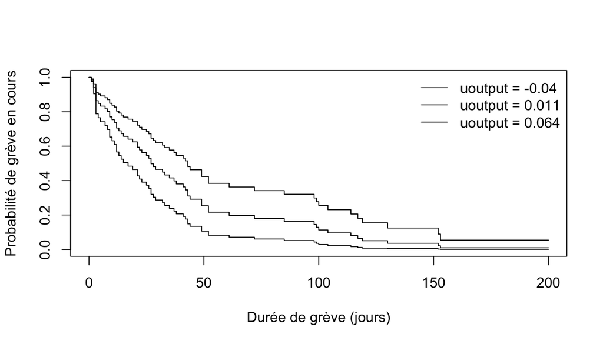

### 7.3.3 Q12 – Interprétation économique

En combinant :

- les **hazard ratios** des modèles de Cox,
- les **courbes de survie** (Kaplan–Meier et prédictions de modèles),

on peut conclure :

- En **période de conjoncture favorable** (choc d’activité positif / fort), les grèves ont plus de chances de se terminer rapidement → **hazard plus élevé**, survie plus faible.
- En **période de conjoncture défavorable**, les grèves ont tendance à durer plus longtemps → **hazard plus faible**, survie plus élevée.

En termes de négociation :

- Quand l’activité est bonne, les employeurs ont davantage de marges (les pertes liées à la grève sont plus coûteuses à court terme), ce qui peut favoriser des **accords plus rapides**.
- Quand la conjoncture est mauvaise, les coûts d’opportunité sont plus faibles et les rapports de force différents, ce qui peut conduire à des grèves **plus longues**.